# QTM 150 Final Project

12/10/2018

### For our project, we chose a dataset focusing on drivers involved in fatal collisions around the United States. The data was collected by the author from NHTSA (National Highway Traffic Safety Administration).

```r
drivers <- read.csv("bad-drivers.csv",
                    col.names = c("State",
                                  "num_drivers_per_billion_miles",
                                  "% _drivers_speeding",
                                  "%_drivers_alcohol_impaired",
                                  "%_drivers_not_distracted",
                                  "%_drivers_no_history",
                                  "car_insurance_premium",
                                  "Losses_per_driver"))
```

## Question 1: What kind of relationship exists between number of drivers involved in fatal collisions per billion miles and average car insurance premium?

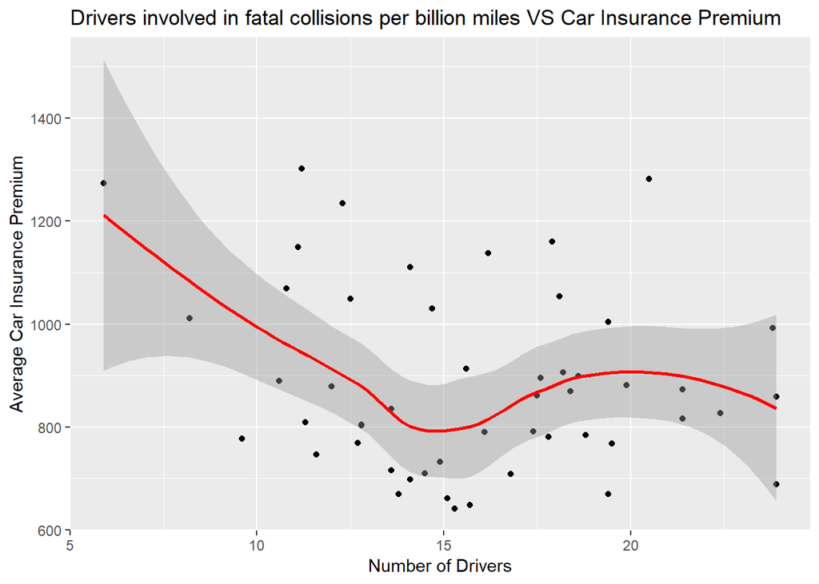

```r
ggplot(drivers, aes(x = num_drivers_per_billion_miles, y = car_insurance_premium)) +
  geom_point() +
  geom_smooth(color = "red", method = "loess", formula = y ~ x) +
  labs(x = "Number of Drivers", y = "Average Car Insurance Premium",
    title = "Drivers involved in fatal collisions per billion miles VS Car Insurance Premium")
```

### It turns out that average car insurance premium and of drivers per billion miles follows a non-linear relationship and there is not a strong correlation between these two variables as there are many outliers.

## Question 2: How does Georgia compare to all others states in terms of average price of car insurance premium that car owners have to pay?

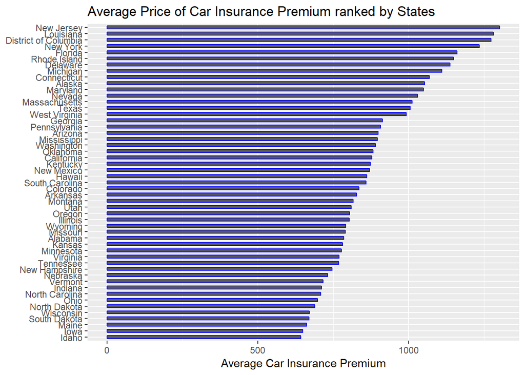

```r
ggplot(drivers, aes(x = reorder(State, car_insurance_premium), y = car_insurance_premium, width = 0.5)) +
  geom_bar(stat = "identity", color = "blue") +
  coord_flip() +
  labs(title = "Average Price of Car Insurance Premium ranked by States", y = "Average Car Insurance Premium", x = NULL)
```

## Question 3: What’s the relationship between insurance premium and the losses incurred for collisions per insured driver?

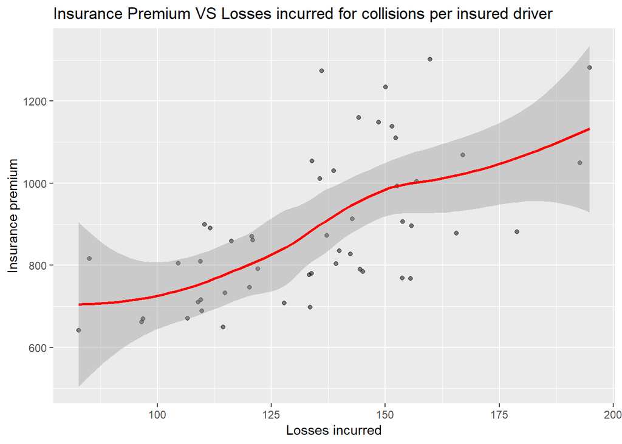

```r
ggplot(drivers, aes(Losses_per_driver, car_insurance_premium)) +
  geom_point(alpha = 0.5) +
  geom_smooth(color="red", method = "loess") +
  labs(x = "Losses incurred", y = "Insurance premium",
       title = "Insurance Premium VS Losses incurred for collisions per insured driver")
```

### As we can see, there’s a general trend that the car insurance premium increases as the losses incurred rises, which indicates a positive relationship between car insurance premium and insurance companies’ losses.